# Coursera Peer Reviewed Project - Practical Machine Learning Week 4 - Using accelerometers to predict if exercise is being performed correctly

Karl Eiholzer

31 December 2016

- Executive Summary
- Preliminary Steps
- Exploratory Data Analysis
- Data Cleaning
- Fitting Multiple Prediction Models
- Simplifying the Random Forest Model
- Conclusions
- Appendix 1: Timestamps and Data
- Appendix 2: Random Forest Data
- Appendix 3: Simplified Random Forest Data
- System and Version Information

### Executive Summary

Skip to Top or next section

##### Preliminaries: load libraries we will be using

Skip to prior section or next section

Loading ggplot2 and caret packages, setting seed and loading in the data files.

### Exploratory Data Analysis

Skip to prior section or next section

The data comes from six test subjects (adelmo, carlitos, charles, eurico, jeremy, and pedro) engaged in five activities (labelled A thru E). As described by the original authors: “Class A corresponds to the specified execution of the exercise, while the other 4 classes correspond to common mistakes. Participants were supervised by an experienced weight lifter to make sure the execution complied to the manner they were supposed to simulate. The exercises were performed by six male participants aged between 20-28 years, with little weight lifting experience. We made sure that all participants could easily simulate the mistakes in a safe and controlled manner by using a relatively light dumbbell (1.25kg).” Accerlometer measurements were captured as the participants exercised. [Read more: http://groupware.les.inf.puc-rio.br/har#ixzz4TZMpuEj6]

We see a well distributed number of observations for each person for each activity, from 469 to 1,177:

```r
with(raw.training, table(classe, user_name))
```

```
##       user_name
## classe adelmo carlitos charles eurico jeremy pedro
##      A   1165      834     899    865   1177   640
##      B    776      690     745    592    489   505
##      C    750      493     539    489    652   499
##      D    515      486     642    582    522   469
##      E    686      609     711    542    562   497
```

Many of the columns appear to be mostly comprised of NA values. The distribution of columns with high rates of NA values suggests on 59 columns are useful as predictors:

```r
NA.rates <- cbind(Column = names(raw.training), Percent.NA = 0, High.NAs = FALSE)
y <- nrow(raw.training)
for(i in 1:length(raw.training) )
  { x <-  round( sum( is.na( raw.training[, i] ) ) / y * 100 , digits = 0 )
    NA.rates[i , 2 ] <- x
    if (x > 95)
      { NA.rates[i , 3 ] <- TRUE
      }
}
table(NA.rates[,2])
```

```
##
##   0 100  98
##  60   6  94
```

Of the 60 columns contain zero NA values, while 100 columns contain 98 or 100 percent NA values.

Also we see that the training data is organized by timestamp. The individuals worked through the various activities from A to E in order each time. Given that we would not normally have access to that information when predicting the activity, we want to build a model that is not dependent on timestamps. Finally we also see that the data is ordered by row number (“X”), which we would also not expect to occur in a normal environment:

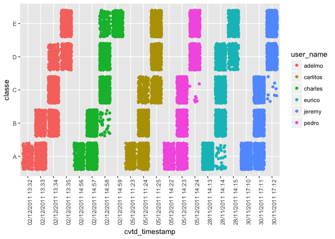

See Appendix 1 for more data on this topic.

```
## [1] FALSE
```

### Data Cleaning

Skip to prior section or next section

I’ll remove the columns that contain mostly NA values and also any columns with near zero variance:

```r
sig.training <- raw.training
for(i in 1:length(raw.training))
    { if( sum( is.na( raw.training[, i] ) ) /nrow(raw.training) >= .95)
      { for(j in 1:length(sig.training))
        { if( length( grep(names(raw.training[i]), names(sig.training)[j]) ) == 1)
          { sig.training <- sig.training[ , -j]
          }
        }
      }
    }

col.no <- which(names(sig.training)=="classe")
nzv <- nearZeroVar(sig.training[, -col.no],
                  freqCut = 99/1,
                  uniqueCut = 5,
                  saveMetrics=TRUE)
nzv.training <- sig.training[,nzv$nzv==FALSE]

dim(nzv.training)
```

```
## [1] 19622    60
```

The near zero variance test does not remove any columns, indicating that any of the remaining columns may be useful for prediction.

Lastly we will remove the user names and timestamp columns, as I believe they will not be useful for prediction. I also shuffle the rows randomly to assist with sampling techniques when fitting and cross validating.

```r
col.no <- which(names(nzv.training)%in%c("user_name","new_window","X","raw_timestamp_part_1","raw_timestamp_part_2","cvtd_timestamp"))
clean.training <- nzv.training[, -col.no]
clean.training <- clean.training[sample(nrow(clean.training)),]
# Clean up the objects
rm(nzv.training)
rm(sig.training)
```

### Fitting a Random Forest Prediction Models

Skip to prior section or next section

After testing kNN, gbm and random forest models, I found the highest accuracy useing random forest. First I train a model using all available predictors.

I start by creating separate training and validation stes:

```r
set.seed(102767)
TrainIndex <- createDataPartition(clean.training$classe,
                                  p = .7,
                                  list = FALSE,
                                  times = 2)
Training <- clean.training[TrainIndex,]
Validation <- clean.training[-TrainIndex,]
```

Due to mimitation of the machine I am using, I will run 100 trees, instead of the recomended 400 or more.

Full informatiomn about the random forest fit may be found in Appendix 2 :

```
## [1] FALSE
```

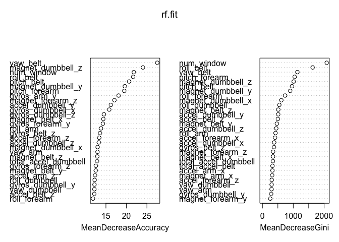

```r
rownames(importance(rf.fit)[1:25,0])
```

```
##  [1] "num_window"       "roll_belt"        "pitch_belt"
##  [4] "yaw_belt"         "total_accel_belt" "gyros_belt_x"
##  [7] "gyros_belt_y"     "gyros_belt_z"     "accel_belt_x"
## [10] "accel_belt_y"     "accel_belt_z"     "magnet_belt_x"
## [13] "magnet_belt_y"    "magnet_belt_z"    "roll_arm"
## [16] "pitch_arm"        "yaw_arm"          "total_accel_arm"
## [19] "gyros_arm_x"      "gyros_arm_y"      "gyros_arm_z"
## [22] "accel_arm_x"      "accel_arm_y"      "accel_arm_z"
## [25] "magnet_arm_x"
```

My next goal will be to create a simpler model with just those predictors.

### Simplifying the Random Forest Model

Skip to prior section or next section

After testing a few smaller sets of predictors, I found that 15 variables would still achieve over 99% accuracy. I also found that accuracy improvements were not found after more than 60 trees. This allows me to run a more simplified version of the model:

```r
set.seed(102767)
key.var <- rownames(importance(rf.fit)[1:15,0])
rf.fit2 <- randomForest(classe ~ .,
                       data = Training[,c("classe",key.var)],
                       ntree=60,
                       importance = TRUE,
                       proximity = TRUE  )
rf.result2 <- predict(rf.fit2, Validation[,c("classe",key.var)])
```

Full informatiomn about the simplified model may be found in Appendix 3 :

```
## [1] FALSE
```

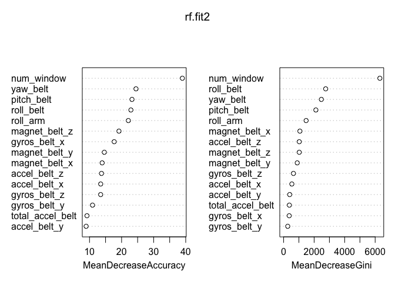

### Conclusions

Skip to prior section or next section

To confirm that the simplified model is as effective as the original full model, we can test both models against the testing data. :

```r
# make columns identical between training and testing sets
col.no <- which(names(testing)%in%as.vector(colnames(Training)))
final.testing1 <- testing[,col.no]
# make columns identical between training and testing sets
col.no <- which(names(testing)%in%as.vector(c("classe",key.var)))
final.testing2 <- testing[,col.no]
# predict results
final.result1 <- predict(rf.fit,  newdata = final.testing1)
final.result2 <- predict(rf.fit2, newdata = final.testing2)
```

A confusion matrix shows that both models return the same results:

```r
confusionMatrix(final.result1, final.result2)$table
```

```
##           Reference
## Prediction A B C D E
##          A 7 0 0 0 0
##          B 0 8 0 0 0
##          C 0 0 1 0 0
##          D 0 0 0 1 0
##          E 0 0 0 0 3
```

Using the simplified model, the final predictions for the test set are as follows:

```r
final.result2
```

```
##  1  2  3  4  5  6  7  8  9 10 11 12 13 14 15 16 17 18 19 20
##  B  A  B  A  A  E  D  B  A  A  B  C  B  A  E  E  A  B  B  B
## Levels: A B C D E
```

#### Appendix 1: Timestamps and Data

```r
con <- file("Documentation/Exercise_Timestamp_data.txt", "r", blocking = FALSE)
readLines("Documentation/Exercise_Timestamp_data.txt")
```

```
##   [1] "##################################################### "
##   [2] "# This is a Log Decsribing Relationships between timestamps and users in the data"
##   [3] "# Created:  Mon Jan  2 08:02:03 2017 "
##   [4] "##################################################### "
##   [5] " "
##   [6] " "
##   [7] ""
##   [8] ", , user_name = adelmo"
##   [9] ""
##  [10] "                  classe"
##  [11] "cvtd_timestamp       A   B   C   D   E"
##  [12] "  02/12/2011 13:32 177   0   0   0   0"
##  [13] "  02/12/2011 13:33 988 333   0   0   0"
##  [14] "  02/12/2011 13:34   0 443 750 182   0"
##  [15] "  02/12/2011 13:35   0   0   0 333 686"
```

[output cut: 145 more lines]

```r
close(con)
```

#### Appendix 2: Log of Random Forest Model Data

```r
con <- file("Documentation/Random_Forest_Model.txt", "r", blocking = FALSE)
readLines("Documentation/Random_Forest_Model.txt")
```

```
##   [1] "##################################################### "
##   [2] "# This is a Log Capturing the Random Forest Tree Results"
##   [3] "# Created:  Mon Jan  2 08:17:40 2017 "
##   [4] "##################################################### "
##   [5] " "
##   [6] " "
##   [7] ""
##   [8] "                             A         B         C         D         E"
##   [9] "num_window           16.024718 20.763105 22.884317 21.042931 18.135973"
##  [10] "roll_belt            15.061804 20.069067 18.121956 21.421957 17.159104"
##  [11] "pitch_belt           11.521232 20.271608 16.186241 18.682291 16.258959"
##  [12] "yaw_belt             17.761668 21.710618 21.203173 21.762556 14.281758"
##  [13] "total_accel_belt      7.985035 10.013000  8.026394  8.324065  7.294517"
##  [14] "gyros_belt_x          6.489707  9.222908  8.962467  6.754466 11.958591"
##  [15] "gyros_belt_y          5.062034  7.525845  6.663050  6.655441  9.447508"
```

[output cut: 108 more lines]

```r
close(con)
```

#### Appendix 3: Log of Simplified Random Forest Model Data

```r
con <- file("Documentation/Random_Forest_Model2.txt", "r", blocking = FALSE)
readLines("Documentation/Random_Forest_Model2.txt")
```

```
##  [1] "##################################################### "
##  [2] "# This is a Log Capturing the Simplified Random Forest Tree Results"
##  [3] "# Created:  Mon Jan  2 08:25:33 2017 "
##  [4] "##################################################### "
##  [5] " "
##  [6] " "
##  [7] ""
##  [8] "Confusion Matrix and Statistics"
##  [9] ""
## [10] "          Reference"
## [11] "Prediction   A   B   C   D   E"
## [12] "         A 499   0   0   0   0"
## [13] "         B   0 347   1   0   0"
## [14] "         C   0   0 316   1   0"
## [15] "         D   0   0   0 299   0"
```

[output cut: 67 more lines]

```r
close(con)
```

#### System and Version Infomation

| Code Origininally Executed on: | Value |
| --- | --- |
| R Version | R version 3.3.2 (2016-10-31) |
| Operating System | darwin13.4.0 |
| Architecture | x86_64 |

Return to top.

File created *Mon Jan 2 08:25:35 2017*